# Ethics

PSCI 2270 - Week 12

Georgiy Syunyaev

Department of Political Science, Vanderbilt University

November 12, 2024

## Plan for this week

1. Ethical concerns in social sciences
2. The Common Rule and IRBs
3. Navigating institutional review

# Ethical concerns in social sciences

## Prominent ethical concerns: Harm

- Risks of harm to human subjects:
  - Historical legacy of Nazi doctors, [Tuskegee Syphilis study](https://www.cdc.gov/tuskegee/about/index.html), [Milgram’s Obedience experiment](https://en.wikipedia.org/wiki/Milgram_experiment), [Zimbardo’s Prison experiment](https://en.wikipedia.org/wiki/Stanford_prison_experiment)
  - Physical or psychological trauma
- Threats to privacy and confidentiality
  - [Historical legacy of Tearoom study](https://en.wikipedia.org/wiki/Tearoom_Trade) and other covert research practices
  - Disclosure of confidential and/or potentially damaging and incriminating information (e.g. in the context of focus groups)
- Concerns about harm go beyond the well-being of subjects to include non-subjects (community, enumerators, researchers, etc.)

## Prominent ethical concerns: Coercion

- Coercion threatens the autonomy of human subjects
  - Experimentation on prisoners, minors or abuses of doctor-patient trust
- Coercion in practice
  - Consent: Participants are not given opportunity to understand the study purposes and procedures, and refuse to participate
  - Compensation: Consider whether the compensation is adequate (not too high!)
  - Deception: Purposeful witholding of crucial information (Tuskegee study)

## Prominent ethical concerns: Justice

- Justice: Burdens of research fall disproportionately on some groups
- Example: medical trials that rely on low income participants
  - Concern: some groups do not enjoy the full benefits of research that relies on their participation
- A different but related concern is that certain groups are passed over when research is conducted

## Other concerns

[figure not shown]

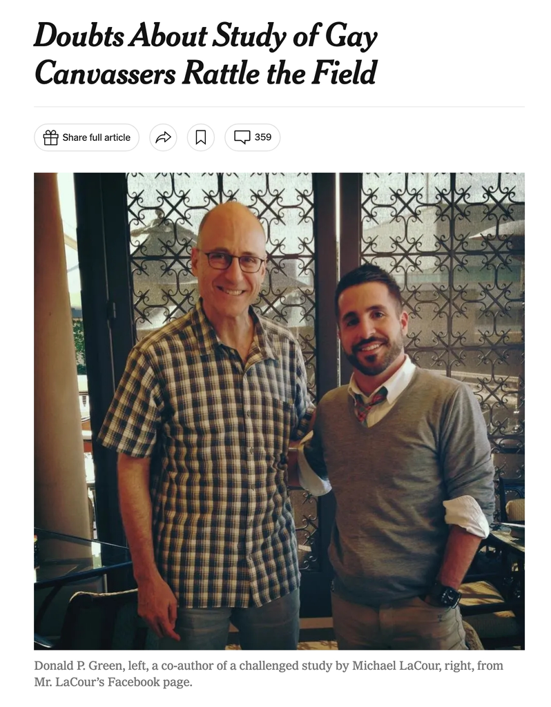

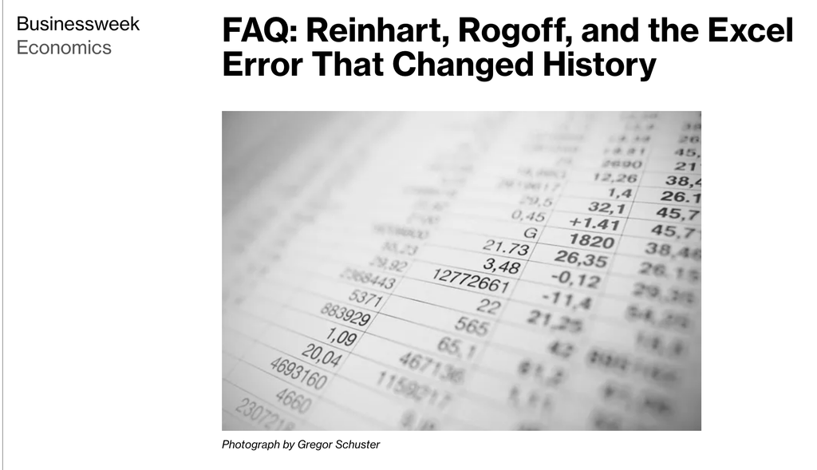

## Other concerns: Professional ethics

- Pursuit and communication of scientific knowledge
  - Honesty when generating and presenting data
  - Methodological rigor
  - Transparency (to both general public and scientific society)
- Appropriate boundaries when gaining access to people or information as a researcher
- Disclosure of conflicts-of-interest
  - Agreements with partners that pertain to selective reporting of research findings
  - Working with entities with which you have personal connections

# The Common Rule and IRBs

## Institutional review

- Code of Federal Regulations: The Common Rule
- Creates Institutional Review Boards (IRBs; Human Subjects Committees) and specifies their jurisdiction and how they are to be constituted
- Required of institutions that receive federal funding, and federal funding can be jeopardized by violations

## Research ethics vs. institutional review

- Institutional review boards focus primarily on the well-being of human subjects
  - Some are also concerned about conflicts-of-interest and proper disclosure of financial ties
  - Some are also concerned with legal or regulatory restrictions on 501c(3) entities: special relevance to political science research that may involve “electioneering”
- Ethical concerns go beyond the well-being of subjects to include non-subjects (community, enumerators, researchers, etc.)

## Research ethics vs. institutional review

- Critics argue that unethical research could be approved by a review board because they are not, fundamentally, ethics review boards
- Conversely, critics have charged that review boards halt or slow research in ways that are ultimately harmful to human subjects (or the broader society)

## Common Rule: What is research?

*“Research means a systematic investigation, including research development, testing, and evaluation, designed to develop or contribute to generalizable knowledge. Activities that meet this definition constitute research for purposes of this policy, whether or not they are conducted or supported under a program that is considered research for other purposes.”*

*“…the following activities are deemed not to be research: (1) Scholarly and journalistic activities (e.g., oral history, journalism, biography, literary criticism, legal research, and historical scholarship), including the collection and use of information, that focus directly on the specific individuals about whom the information is collected.”*

## Common Rule: Human subjects

*Human subject means a living individual about whom an investigator (whether professional or student) is conducting research:*

1. *Obtains information or biospecimens through intervention or interaction with the individual, and, uses, studies, or analyzes the information or biospecimens; or*
2. *Obtains, uses, studies, analyzes, or generates identifiable private information or identifiable biospecimens.*
- Politicians in audit experiments? No!
- Tasters in experiments where they are asked to try different products to compare their features? No!
- Using publicly available datasets, like survey data from ANES? Likely No!

## Common Rule: Risks and vulnarability

*“Minimal risk means that the probability and magnitude of harm or discomfort anticipated in the research are not greater in and of themselves than those ordinarily encountered in daily life or during the performance of routine physical or psychological examinations or tests.”*

*“When some or all of the subjects are likely to be vulnerable to coercion or undue influence, such as children, prisoners, individuals with impaired decision-making capacity, or economically or educationally disadvantaged persons, additional safeguards have been included in the study to protect the rights and welfare of these subjects.”*

## Common Rule: Informed consent

*In order for an IRB to waive or alter consent… the IRB must find and document that:*

1. *The research involves no more than minimal risk to the subjects;*
2. *The research could not practicably be carried out without the requested waiver or alteration;*
3. *If the research involves using identifiable private information or identifiable biospecimens, the research could not practicably be carried out without using such information or biospecimens in an identifiable format;*
4. *The waiver or alteration will not adversely affect the rights and welfare of the subjects; and;*
5. *Whenever appropriate, the subjects or legally authorized representatives will be provided with additional pertinent information after participation.*

## Exempt and expedited

- Exempt research
  - Tests of ordinary education practices that ensure confidentiality
  - Benign interventions: behavioral interventions are brief in duration, harmless, painless, not physically invasive, not likely to have a significant adverse lasting impact on the subjects, and the investigator has no reason to think the subjects will find the interventions offensive or embarrassing
  - Taste testing
- Expedited review
  - No more than minimal risk AND explicit consent from participants $\Rightarrow$ Survey research
  - No more than minimal risk AND observation of public outcomes

## Is it ethical?

- If you would be reviewing ethics of the following projects, would you *approve it as is*, *request a modification (what exactly?)*, or *halt it*?
  - Participants sign up for a study on news readership habits. The researcher subtly modifies the political content in newsletters they receive to assess changes in their political opinions.
  - Conducting anonymous interviews with individuals who attended recent demonstrations, some of which involved violence, to understand motivations behind political protests.
  - Distributing questionnaires to high school students about their views on controversial political issues, offering extra credit as an incentive.
  - In a lab setting, participants are shown graphic images from war zones to study the impact on their political attitudes.
  - Researchers study emails between politicians that were released without authorization, aiming to understand decision-making processes within political parties.
  - Researchers travel to areas with ongoing political conflict to interview locals about their experiences.

# Navigating institutional review

## In practice: Consent

- *(From [APSA Guidelines](https://www.apsanet.org/Portals/54/diversity%20and%20inclusion%20prgms/Ethics/Final_Principles%20with%20Guidance%20with%20intro.pdf?ver=2020-04-20-211740-153))* In general, when seeking consent, researchers should usually communicate:
  - researcher name and affiliation (and contact information when appropriate)
  - the general purpose of the research
  - an explanation of what participation entails
  - potential risks to participants
  - potential benefits to participants and others (or clarification that none are expected)
  - whether and how identities and data will be protected
  - sources of financial support for the research (this is essential for participants to assess risk in some settings, including conflict zones or polarized political settings)
  - any other information relevant to the study, setting, or context.

## In practice: Consent

[figure not shown]

- **For those doing human subjects project, please attach draft consent form to your final write-up!**

## In practice: Debriefing

- Sometimes your research design requires to **withhold crucial information from subjects** during consent.
  - *Examples: Withhold treatment from subjects without letting them know, misrepresent purposes of the study, lie to subjects about what they will have to do.*
- If your study has high academic/practical importance it can still be approved
  - You should include a statement explaining the purpose and nature of deception, debrief, at the end of the study, to make sure they are informed and can contact you or IRB later
- Some IRBs consider any experiments a form of deception…

## In practice: Training and submission

- Vandy is a bit complicated: Has two separate procedures for domestic and international projects
  - More information [here](https://www.vanderbilt.edu/researchintegrityandcompliance/human-subjects-research/)
- You are required to complete Human Subjects Training provided by CITI.
  - You can do it through Vandy for free [here](https://about.citiprogram.org/) (read guide [here](https://www.vumc.org/irb/sites/default/files/public_files/Training_Education/CITI-Tutorial-Instructions.pdf))
  - You need to complete the basic module and submit certificate to Brightspace or OSF
- Submit the project protocol for domestic research [here](https://irb.app.vumc.org/investigator) and for international research [here](https://www.vanderbilt.edu/researchintegrityandcompliance/human-subjects-research/brany-instructions/)
- It’s a bit of a nightmare, but changes are in sight…😔